# A summary of the tweets generated at the 2015 Ecological Society of America meeting (#ESA100)

EJ Rollinson

## About this document

The code generating this document was originally developed by François Michonneau [(fmic_)](https://twitter.com/fmic_) for the 2015 Evolution conference, and since adapted for ICCB-ECCB 2015 by Joona Lehtomäki [(jlehtoma)](https://twitter.com/jlehtoma). Thanks also to Emily Sessa [(ebsessa)](http://twitter.com/ebsessa) for reproducing this code for the Botany 2015 conference on Twitter, bringing it to my attention.

Here, the code is adapted for the 2015 Ecological Society of America Meeting (ESA100) by Emily J. Rollinson [(katteken)](https://twitter.com/katteken).

This document was generated using RMarkdown, and the source is [available on GitHub](https://github.com/erollinson/ESA100-tweets). The original code by fmichonneau is [here](https://github.com/fmichonneau/evol2015-tweets).

Tweets using the hashtag #ESA100 were aggregated from Twitter using the R package [twitteR](https://cran.r-project.org/web/packages/twitteR/index.html) and the Twitter API. The aggregated tweets are [available on Figshare](http://dx.doi.org/10.6084/m9.figshare.1512350).

This document (and associated code) is released under a CC0 licence.

## Basic summary

Of the most recent 10k tweets tagged #ESA100 (As of 9:00 PM 8/15/2015):

| Description | n |
| --- | --- |
| *Total of original tweets (no retweets):* | 4396 |
| *Number of users who tweeted:* | 1993 |

## The 5 most favorited tweets

> Theoreticians: stop telling us not to be scared of your equations. I’m not. Explain them well, like I do my methods, then continue #ESA100

> — jhpantel | [2015-08-12](https://twitter.com/jhpantel/status/631443301946621952) | 93 retweets, 115 favorites.

> One of the nicest things you can do at meetings is to acknowledge the students trying to catch your eye and introduce themselves. #ESA100

> — JacquelynGill | [2015-08-11](https://twitter.com/JacquelynGill/status/631179653127012352) | 49 retweets, 104 favorites.

> Hi #ESA100, please favorite this if you are interested in finding a way to convince the society to give a budget line to support @ESA_SEEDS.

> — hormiga | [2015-08-13](https://twitter.com/hormiga/status/631625250153758720) | 17 retweets, 83 favorites.

> Idea for next year: a student Bingo card. I.e., “Ask a question,” “introduce yourself,” “go to a talk outside your discipline.” #esa100

> — JacquelynGill | [2015-08-13](https://twitter.com/JacquelynGill/status/631920649762574336) | 10 retweets, 45 favorites.

> My take from #ESA100 so far: Ecology is actually a loose collection of disciplinary silos that barely communicate.

> — tpoi | [2015-08-13](https://twitter.com/tpoi/status/631807105914281984) | 16 retweets, 33 favorites.

## The 5 most retweeted tweets

> Theoreticians: stop telling us not to be scared of your equations. I’m not. Explain them well, like I do my methods, then continue #ESA100

> — jhpantel | [2015-08-12](https://twitter.com/jhpantel/status/631443301946621952) | 93 retweets, 115 favorites.

> One of the nicest things you can do at meetings is to acknowledge the students trying to catch your eye and introduce themselves. #ESA100

> — JacquelynGill | [2015-08-11](https://twitter.com/JacquelynGill/status/631179653127012352) | 49 retweets, 104 favorites.

> Tenure track job in ecological modelling with @JaneElith & the rest of us at @qaecology https://t.co/44jCNxRBiZ #ESA100

> — mickresearch | [2015-08-13](https://twitter.com/mickresearch/status/631820012987133952) | 48 retweets, 12 favorites.

> #ESA100 The world is big. Scientists are relatively small. Collaborate.

> — cjlortie | [2015-08-12](https://twitter.com/cjlortie/status/631446967676207104) | 33 retweets, 30 favorites.

> This is what students see: fewer women speaking. Imagine gender equality for ESA 2016. #ESA100 @ESA_org #WomenInSTEM http://t.co/irs3QmStKD

> — Laura_J_Martin | [2015-08-12](https://twitter.com/Laura_J_Martin/status/631553305311719424) | 31 retweets, 15 favorites.

## Top tweeters

All generated tweets (including retweets)

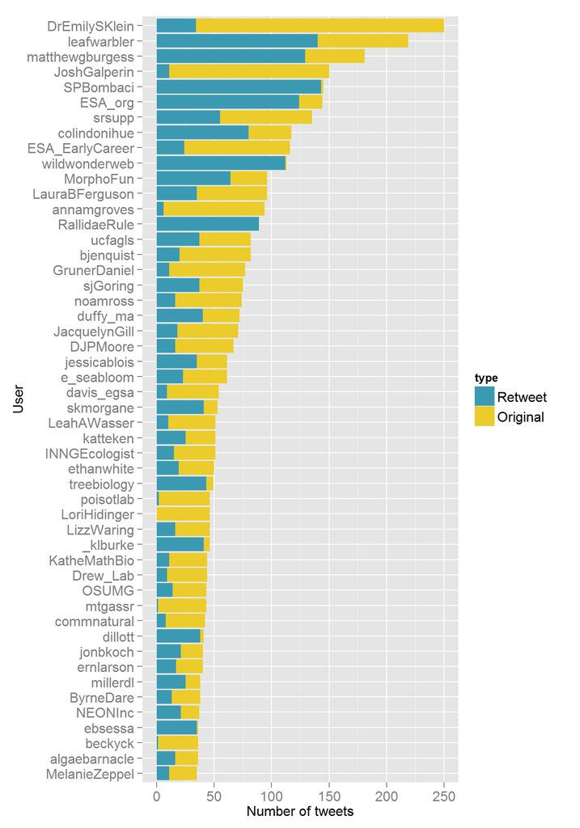

Only for original tweets (retweets excluded)

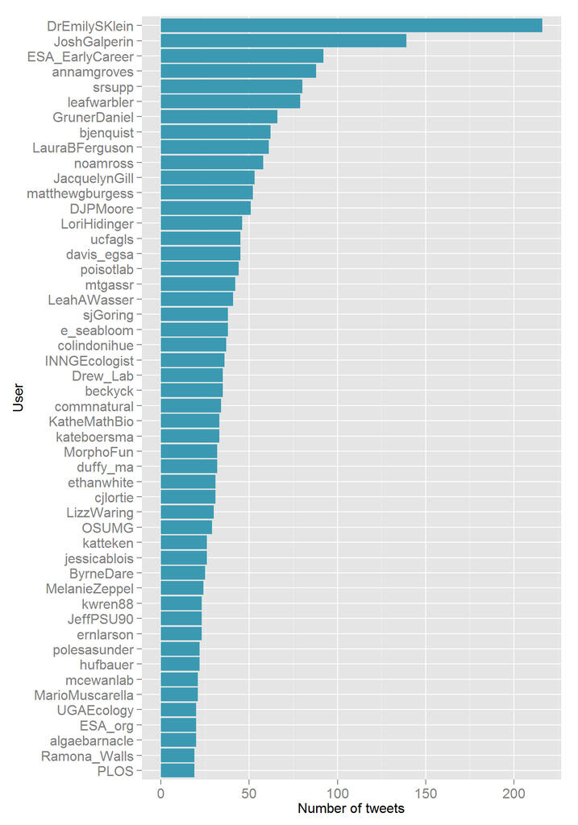

## Most favorited/retweeted users

The figures below only include users who tweeted 5+ times, and don’t include retweets.

### Number of favorites received by users

[figure not shown]

### Number of retweets received by users

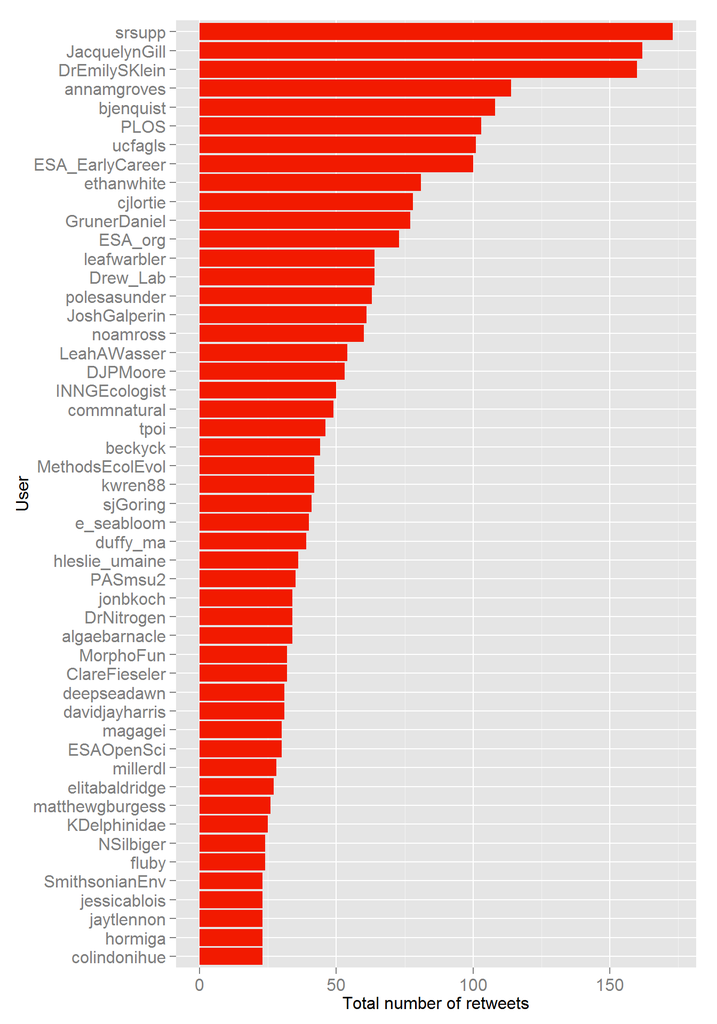

### Mean numbers of favorites received

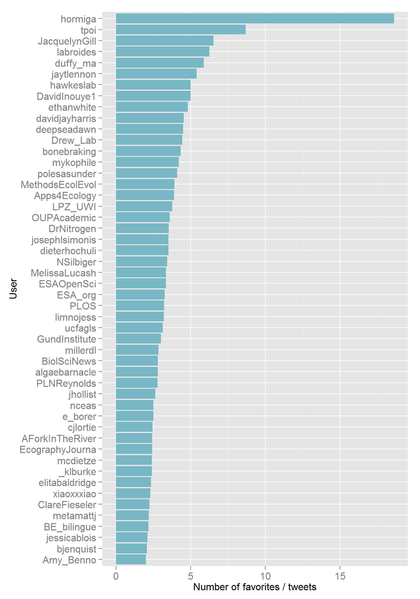

### Mean numbers of retweets received

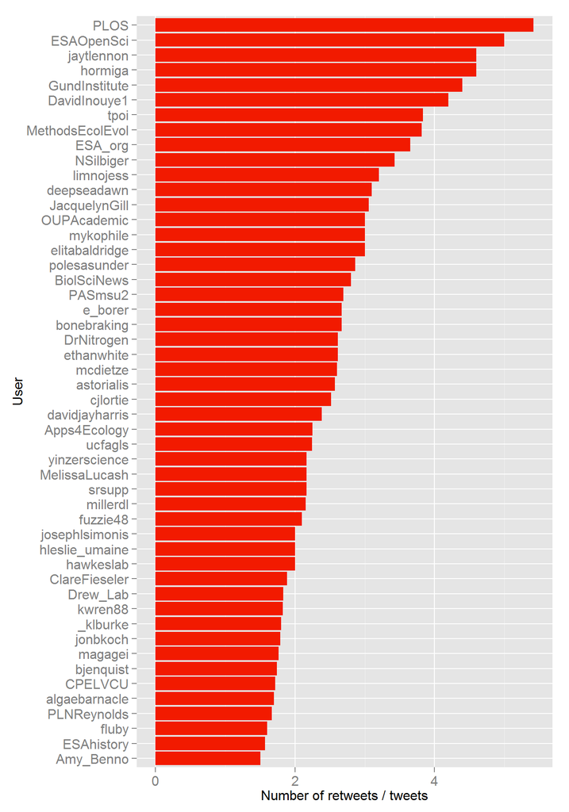

## Word cloud

The top 100 words among the original tweets.

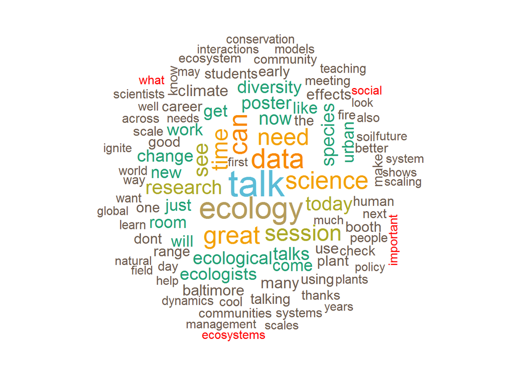

To the extent possible under law, [Emily J. Rollinson](https://github.com/fmichonneau/evol2015-tweets) has waived all copyright and related or neighboring rights to Summary of tweets at the 2015 Ecological Society of America conference. This work is published from: United States.